# exploratory

### Test

```python
newdf_movie.iloc[:,:18]
```

|  | id | imdb_id | popularity | budget | revenue | original_title | cast | director | tagline | runtime | release_date | vote_count | vote_average | release_year | budget_adj | revenue_adj | Action | Adventure |
| --- | --- | --- | --- | --- | --- | --- | --- | --- | --- | --- | --- | --- | --- | --- | --- | --- | --- | --- |
| 0 | 135397 | tt0369610 | 32.985763 | 150000000 | 1513528810 | Jurassic World | Chris Pratt\|Bryce Dallas Howard\|Irrfan Khan\|Vi... | Colin Trevorrow | The park is open. | 124 | 6/9/15 | 5562 | 6.5 | 2015 | 1.379999e+08 | 1.392446e+09 | 1 | 1 |
| 1 | 76341 | tt1392190 | 28.419936 | 150000000 | 378436354 | Mad Max: Fury Road | Tom Hardy\|Charlize Theron\|Hugh Keays-Byrne\|Nic... | George Miller | What a Lovely Day. | 120 | 5/13/15 | 6185 | 7.1 | 2015 | 1.379999e+08 | 3.481613e+08 | 1 | 1 |
| 2 | 262500 | tt2908446 | 13.112507 | 110000000 | 295238201 | Insurgent | Shailene Woodley\|Theo James\|Kate Winslet\|Ansel... | Robert Schwentke | One Choice Can Destroy You | 119 | 3/18/15 | 2480 | 6.3 | 2015 | 1.012000e+08 | 2.716190e+08 | 0 | 1 |
| 3 | 140607 | tt2488496 | 11.173104 | 200000000 | 2068178225 | Star Wars: The Force Awakens | Harrison Ford\|Mark Hamill\|Carrie Fisher\|Adam D... | J.J. Abrams | Every generation has a story. | 136 | 12/15/15 | 5292 | 7.5 | 2015 | 1.839999e+08 | 1.902723e+09 | 1 | 1 |
| 4 | 168259 | tt2820852 | 9.335014 | 190000000 | 1506249360 | Furious 7 | Vin Diesel\|Paul Walker\|Jason Statham\|Michelle ... | James Wan | Vengeance Hits Home | 137 | 4/1/15 | 2947 | 7.3 | 2015 | 1.747999e+08 | 1.385749e+09 | 1 | 0 |
| 5 | 281957 | tt1663202 | 9.110700 | 135000000 | 532950503 | The Revenant | Leonardo DiCaprio\|Tom Hardy\|Will Poulter\|Domhn... | Alejandro González Iñárritu | (n. One who has returned, as if from the dead.) | 156 | 12/25/15 | 3929 | 7.2 | 2015 | 1.241999e+08 | 4.903142e+08 | 0 | 1 |
| 6 | 87101 | tt1340138 | 8.654359 | 155000000 | 440603537 | Terminator Genisys | Arnold Schwarzenegger\|Jason Clarke\|Emilia Clar... | Alan Taylor | Reset the future | 125 | 6/23/15 | 2598 | 5.8 | 2015 | 1.425999e+08 | 4.053551e+08 | 1 | 1 |
| 7 | 286217 | tt3659388 | 7.667400 | 108000000 | 595380321 | The Martian | Matt Damon\|Jessica Chastain\|Kristen Wiig\|Jeff ... | Ridley Scott | Bring Him Home | 141 | 9/30/15 | 4572 | 7.6 | 2015 | 9.935996e+07 | 5.477497e+08 | 0 | 1 |
| 8 | 211672 | tt2293640 | 7.404165 | 74000000 | 1156730962 | Minions | Sandra Bullock\|Jon Hamm\|Michael Keaton\|Allison... | Kyle Balda\|Pierre Coffin | Before Gru, they had a history of bad bosses | 91 | 6/17/15 | 2893 | 6.5 | 2015 | 6.807997e+07 | 1.064192e+09 | 0 | 1 |
| 9 | 150540 | tt2096673 | 6.326804 | 175000000 | 853708609 | Inside Out | Amy Poehler\|Phyllis Smith\|Richard Kind\|Bill Ha... | Pete Docter | Meet the little voices inside your head. | 94 | 6/9/15 | 3935 | 8.0 | 2015 | 1.609999e+08 | 7.854116e+08 | 0 | 0 |
| 10 | 206647 | tt2379713 | 6.200282 | 245000000 | 880674609 | Spectre | Daniel Craig\|Christoph Waltz\|Léa Seydoux\|Ralp... | Sam Mendes | A Plan No One Escapes | 148 | 10/26/15 | 3254 | 6.2 | 2015 | 2.253999e+08 | 8.102203e+08 | 1 | 1 |
| 11 | 76757 | tt1617661 | 6.189369 | 176000003 | 183987723 | Jupiter Ascending | Mila Kunis\|Channing Tatum\|Sean Bean\|Eddie Redm... | Lana Wachowski\|Lilly Wachowski | Expand your universe. | 124 | 2/4/15 | 1937 | 5.2 | 2015 | 1.619199e+08 | 1.692686e+08 | 1 | 1 |
| 12 | 264660 | tt0470752 | 6.118847 | 15000000 | 36869414 | Ex Machina | Domhnall Gleeson\|Alicia Vikander\|Oscar Isaac\|S... | Alex Garland | There is nothing more human than the will to s... | 108 | 1/21/15 | 2854 | 7.6 | 2015 | 1.379999e+07 | 3.391985e+07 | 0 | 0 |
| 13 | 257344 | tt2120120 | 5.984995 | 88000000 | 243637091 | Pixels | Adam Sandler\|Michelle Monaghan\|Peter Dinklage\|... | Chris Columbus | Game On. | 105 | 7/16/15 | 1575 | 5.8 | 2015 | 8.095996e+07 | 2.241460e+08 | 1 | 0 |
| 14 | 99861 | tt2395427 | 5.944927 | 280000000 | 1405035767 | Avengers: Age of Ultron | Robert Downey Jr.\|Chris Hemsworth\|Mark Ruffalo... | Joss Whedon | A New Age Has Come. | 141 | 4/22/15 | 4304 | 7.4 | 2015 | 2.575999e+08 | 1.292632e+09 | 1 | 1 |
| 15 | 273248 | tt3460252 | 5.898400 | 44000000 | 155760117 | The Hateful Eight | Samuel L. Jackson\|Kurt Russell\|Jennifer Jason ... | Quentin Tarantino | No one comes up here without a damn good reason. | 167 | 12/25/15 | 2389 | 7.4 | 2015 | 4.047998e+07 | 1.432992e+08 | 0 | 0 |
| 16 | 260346 | tt2446042 | 5.749758 | 48000000 | 325771424 | Taken 3 | Liam Neeson\|Forest Whitaker\|Maggie Grace\|Famke... | Olivier Megaton | It Ends Here | 109 | 1/1/15 | 1578 | 6.1 | 2015 | 4.415998e+07 | 2.997096e+08 | 1 | 0 |
| 17 | 102899 | tt0478970 | 5.573184 | 130000000 | 518602163 | Ant-Man | Paul Rudd\|Michael Douglas\|Evangeline Lilly\|Cor... | Peyton Reed | Heroes Don't Get Any Bigger | 115 | 7/14/15 | 3779 | 7.0 | 2015 | 1.195999e+08 | 4.771138e+08 | 1 | 1 |
| 18 | 150689 | tt1661199 | 5.556818 | 95000000 | 542351353 | Cinderella | Lily James\|Cate Blanchett\|Richard Madden\|Helen... | Kenneth Branagh | Midnight is just the beginning. | 112 | 3/12/15 | 1495 | 6.8 | 2015 | 8.739996e+07 | 4.989630e+08 | 0 | 0 |
| 19 | 131634 | tt1951266 | 5.476958 | 160000000 | 650523427 | The Hunger Games: Mockingjay - Part 2 | Jennifer Lawrence\|Josh Hutcherson\|Liam Hemswor... | Francis Lawrence | The fire will burn forever. | 136 | 11/18/15 | 2380 | 6.5 | 2015 | 1.471999e+08 | 5.984813e+08 | 0 | 1 |
| 20 | 158852 | tt1964418 | 5.462138 | 190000000 | 209035668 | Tomorrowland | Britt Robertson\|George Clooney\|Raffey Cassidy\|... | Brad Bird | Imagine a world where nothing is impossible. | 130 | 5/19/15 | 1899 | 6.2 | 2015 | 1.747999e+08 | 1.923127e+08 | 1 | 1 |
| 21 | 307081 | tt1798684 | 5.337064 | 30000000 | 91709827 | Southpaw | Jake Gyllenhaal\|Rachel McAdams\|Forest Whitaker... | Antoine Fuqua | Believe in Hope. | 123 | 6/15/15 | 1386 | 7.3 | 2015 | 2.759999e+07 | 8.437300e+07 | 1 | 0 |
| 22 | 254128 | tt2126355 | 4.907832 | 110000000 | 470490832 | San Andreas | Dwayne Johnson\|Alexandra Daddario\|Carla Gugino... | Brad Peyton | A rescue pilot survived an earthquake, this is... | 114 | 5/27/15 | 2060 | 6.1 | 2015 | 1.012000e+08 | 4.328514e+08 | 1 | 0 |
| 23 | 216015 | tt2322441 | 4.710402 | 40000000 | 569651467 | Fifty Shades of Grey | Dakota Johnson\|Jamie Dornan\|Jennifer Ehle\|Eloi... | Sam Taylor-Johnson | Are you curious? | 125 | 2/11/15 | 1865 | 5.3 | 2015 | 3.679998e+07 | 5.240791e+08 | 0 | 0 |
| 24 | 318846 | tt1596363 | 4.648046 | 28000000 | 133346506 | The Big Short | Christian Bale\|Steve Carell\|Ryan Gosling\|Brad ... | Adam McKay | This is a true story. | 130 | 12/11/15 | 1545 | 7.3 | 2015 | 2.575999e+07 | 1.226787e+08 | 0 | 0 |
| 25 | 177677 | tt2381249 | 4.566713 | 150000000 | 682330139 | Mission: Impossible - Rogue Nation | Tom Cruise\|Jeremy Renner\|Simon Pegg\|Rebecca Fe... | Christopher McQuarrie | Desperate Times. Desperate Measures. | 131 | 7/23/15 | 2349 | 7.1 | 2015 | 1.379999e+08 | 6.277435e+08 | 1 | 0 |
| 26 | 214756 | tt2637276 | 4.564549 | 68000000 | 215863606 | Ted 2 | Mark Wahlberg\|Seth MacFarlane\|Amanda Seyfried\|... | Seth MacFarlane | Ted is Coming, Again. | 115 | 6/25/15 | 1666 | 6.3 | 2015 | 6.255997e+07 | 1.985944e+08 | 0 | 0 |
| 27 | 207703 | tt2802144 | 4.503789 | 81000000 | 403802136 | Kingsman: The Secret Service | Taron Egerton\|Colin Firth\|Samuel L. Jackson\|Mi... | Matthew Vaughn | Manners maketh man. | 130 | 1/24/15 | 3833 | 7.6 | 2015 | 7.451997e+07 | 3.714978e+08 | 1 | 1 |
| 28 | 314365 | tt1895587 | 4.062293 | 20000000 | 88346473 | Spotlight | Mark Ruffalo\|Michael Keaton\|Rachel McAdams\|Lie... | Tom McCarthy | Break the story. Break the silence. | 128 | 11/6/15 | 1559 | 7.8 | 2015 | 1.839999e+07 | 8.127872e+07 | 0 | 0 |
| 29 | 294254 | tt4046784 | 3.968891 | 61000000 | 311256926 | Maze Runner: The Scorch Trials | Dylan O'Brien\|Kaya Scodelario\|Thomas Brodie-Sa... | Wes Ball | The Maze Was Just the Beginning. | 132 | 9/9/15 | 1849 | 6.4 | 2015 | 5.611998e+07 | 2.863562e+08 | 1 | 0 |
| ... | ... | ... | ... | ... | ... | ... | ... | ... | ... | ... | ... | ... | ... | ... | ... | ... | ... | ... |
| 10836 | 38720 | tt0061170 | 0.239435 | 14678640 | 10824 | Walk Don't Run | Cary Grant\|Samantha Eggar\|Jim Hutton\|John Stan... | Charles Walters | Run, don't walk to see Walk, Don't Run. | 114 | 1/1/66 | 11 | 5.8 | 1966 | 0.000000e+00 | 0.000000e+00 | 0 | 0 |
| 10837 | 19728 | tt0060177 | 0.291704 | 14678640 | 10824 | The Blue Max | George Peppard\|James Mason\|Ursula Andress\|Jere... | John Guillermin | There was no quiet on the Western Front! | 156 | 6/21/66 | 12 | 5.5 | 1966 | 0.000000e+00 | 0.000000e+00 | 1 | 1 |
| 10838 | 22383 | tt0060862 | 0.151845 | 14678640 | 10824 | The Professionals | Burt Lancaster\|Lee Marvin\|Robert Ryan\|Woody St... | Richard Brooks | Rough, tough and ready. | 117 | 11/1/66 | 21 | 6.0 | 1966 | 0.000000e+00 | 0.000000e+00 | 1 | 1 |
| 10839 | 13353 | tt0060550 | 0.276133 | 14678640 | 10824 | It's the Great Pumpkin, Charlie Brown | Christopher Shea\|Sally Dryer\|Kathy Steinberg\|A... | Bill Melendez | Every year he rises from the pumpkin patch... | 25 | 10/27/66 | 49 | 7.2 | 1966 | 0.000000e+00 | 0.000000e+00 | 0 | 0 |
| 10840 | 34388 | tt0060437 | 0.102530 | 14678640 | 10824 | Funeral in Berlin | Michael Caine\|Paul Hubschmid\|Oskar Homolka\|Eva... | Guy Hamilton | NaN | 102 | 12/22/66 | 13 | 5.7 | 1966 | 0.000000e+00 | 0.000000e+00 | 0 | 0 |
| 10841 | 42701 | tt0062262 | 0.264925 | 75000 | 10824 | The Shooting | Will Hutchins\|Millie Perkins\|Jack Nicholson\|Wa... | Monte Hellman | Suspenseful desert pursuit in the "High Noon" ... | 82 | 10/23/66 | 12 | 5.5 | 1966 | 5.038511e+05 | 0.000000e+00 | 0 | 0 |
| 10842 | 36540 | tt0061199 | 0.253437 | 14678640 | 10824 | Winnie the Pooh and the Honey Tree | Sterling Holloway\|Junius Matthews\|Sebastian Ca... | Wolfgang Reitherman | NaN | 25 | 1/1/66 | 12 | 7.9 | 1966 | 0.000000e+00 | 0.000000e+00 | 0 | 0 |
| 10843 | 29710 | tt0060588 | 0.252399 | 14678640 | 10824 | Khartoum | Charlton Heston\|Laurence Olivier\|Richard Johns... | Basil Dearden\|Eliot Elisofon | Where the Nile divides, the great Cinerama adv... | 134 | 6/9/66 | 12 | 5.8 | 1966 | 0.000000e+00 | 0.000000e+00 | 1 | 1 |
| 10844 | 23728 | tt0059557 | 0.236098 | 14678640 | 10824 | Our Man Flint | James Coburn\|Lee J. Cobb\|Gila Golan\|Edward Mul... | Daniel Mann | The ORIGINAL man of mystery! | 108 | 1/16/66 | 13 | 5.6 | 1966 | 0.000000e+00 | 0.000000e+00 | 0 | 1 |
| 10845 | 5065 | tt0059014 | 0.230873 | 14678640 | 10824 | Carry On Cowboy | Sid James\|Jim Dale\|Angela Douglas\|Kenneth Will... | Gerald Thomas | How the west was lost! | 93 | 3/1/66 | 15 | 5.9 | 1966 | 0.000000e+00 | 0.000000e+00 | 0 | 0 |
| 10846 | 17102 | tt0059127 | 0.212716 | 14678640 | 10824 | Dracula: Prince of Darkness | Christopher Lee\|Barbara Shelley\|Andrew Keir\|Fr... | Terence Fisher | DEAD for Ten Years DRACULA, Prince of Darkness... | 90 | 1/9/66 | 16 | 5.7 | 1966 | 0.000000e+00 | 0.000000e+00 | 0 | 0 |
| 10847 | 28763 | tt0060548 | 0.034555 | 14678640 | 10824 | Island of Terror | Peter Cushing\|Edward Judd\|Carole Gray\|Eddie By... | Terence Fisher | How could they stop the devouring death...that... | 89 | 6/20/66 | 13 | 5.3 | 1966 | 0.000000e+00 | 0.000000e+00 | 0 | 0 |
| 10848 | 2161 | tt0060397 | 0.207257 | 5115000 | 12000000 | Fantastic Voyage | Stephen Boyd\|Raquel Welch\|Edmond O'Brien\|Donal... | Richard Fleischer | A Fantastic and Spectacular Voyage... Through ... | 100 | 8/24/66 | 42 | 6.7 | 1966 | 3.436265e+07 | 8.061618e+07 | 0 | 1 |
| 10849 | 28270 | tt0060445 | 0.206537 | 14678640 | 10824 | Gambit | Michael Caine\|Shirley MacLaine\|Herbert Lom\|Joh... | Ronald Neame | Shirley MacLaine raises Michael Caine! | 109 | 12/16/66 | 14 | 6.1 | 1966 | 0.000000e+00 | 0.000000e+00 | 1 | 0 |
| 10850 | 26268 | tt0060490 | 0.202473 | 14678640 | 10824 | Harper | Paul Newman\|Lauren Bacall\|Julie Harris\|Arthur ... | Jack Smight | Harper takes a case - and the payoff is murder. | 121 | 2/23/66 | 14 | 6.0 | 1966 | 0.000000e+00 | 0.000000e+00 | 1 | 0 |
| 10851 | 15347 | tt0060182 | 0.342791 | 14678640 | 10824 | Born Free | Virginia McKenna\|Bill Travers\|Geoffrey Keen\|Pe... | James Hill | From The Pages Of The Beloved Best Seller... A... | 95 | 6/22/66 | 15 | 6.6 | 1966 | 0.000000e+00 | 0.000000e+00 | 1 | 1 |
| 10852 | 37301 | tt0060165 | 0.227220 | 14678640 | 10824 | A Big Hand for the Little Lady | Henry Fonda\|Joanne Woodward\|Jason Robards\|Paul... | Fielder Cook | All the action you can take...all the adventur... | 95 | 5/31/66 | 11 | 6.0 | 1966 | 0.000000e+00 | 0.000000e+00 | 0 | 0 |
| 10853 | 15598 | tt0060086 | 0.163592 | 14678640 | 10824 | Alfie | Michael Caine\|Shelley Winters\|Millicent Martin... | Lewis Gilbert | Is any man an Alfie? Ask any girl! | 114 | 3/29/66 | 26 | 6.2 | 1966 | 0.000000e+00 | 0.000000e+00 | 0 | 0 |
| 10854 | 31602 | tt0060232 | 0.146402 | 14678640 | 10824 | The Chase | Marlon Brando\|Jane Fonda\|Robert Redford\|E.G. M... | Arthur Penn | The chase is on! | 135 | 2/17/66 | 17 | 6.0 | 1966 | 0.000000e+00 | 0.000000e+00 | 0 | 0 |
| 10855 | 13343 | tt0059221 | 0.141026 | 700000 | 10824 | The Ghost & Mr. Chicken | Don Knotts\|Joan Staley\|Liam Redmond\|Dick Sarge... | Alan Rafkin | G-G-GUARANTEED! YOU'LL BE SCARED UNTIL YOU LAU... | 90 | 1/20/66 | 14 | 6.1 | 1966 | 4.702610e+06 | 0.000000e+00 | 0 | 0 |
| 10856 | 20277 | tt0061135 | 0.140934 | 14678640 | 10824 | The Ugly Dachshund | Dean Jones\|Suzanne Pleshette\|Charles Ruggles\|K... | Norman Tokar | A HAPPY HONEYMOON GOES TO THE DOGS!...When a G... | 93 | 2/16/66 | 14 | 5.7 | 1966 | 0.000000e+00 | 0.000000e+00 | 0 | 0 |
| 10857 | 5921 | tt0060748 | 0.131378 | 14678640 | 10824 | Nevada Smith | Steve McQueen\|Karl Malden\|Brian Keith\|Arthur K... | Henry Hathaway | Some called him savage- and some called him sa... | 128 | 6/10/66 | 10 | 5.9 | 1966 | 0.000000e+00 | 0.000000e+00 | 1 | 0 |
| 10858 | 31918 | tt0060921 | 0.317824 | 14678640 | 10824 | The Russians Are Coming, The Russians Are Coming | Carl Reiner\|Eva Marie Saint\|Alan Arkin\|Brian K... | Norman Jewison | IT'S A PLOT! ...to make the world die laughing!! | 126 | 5/25/66 | 11 | 5.5 | 1966 | 0.000000e+00 | 0.000000e+00 | 0 | 0 |
| 10859 | 20620 | tt0060955 | 0.089072 | 14678640 | 10824 | Seconds | Rock Hudson\|Salome Jens\|John Randolph\|Will Gee... | John Frankenheimer | NaN | 100 | 10/5/66 | 22 | 6.6 | 1966 | 0.000000e+00 | 0.000000e+00 | 0 | 0 |
| 10860 | 5060 | tt0060214 | 0.087034 | 14678640 | 10824 | Carry On Screaming! | Kenneth Williams\|Jim Dale\|Harry H. Corbett\|Joa... | Gerald Thomas | Carry On Screaming with the Hilarious CARRY ON... | 87 | 5/20/66 | 13 | 7.0 | 1966 | 0.000000e+00 | 0.000000e+00 | 0 | 0 |
| 10861 | 21 | tt0060371 | 0.080598 | 14678640 | 10824 | The Endless Summer | Michael Hynson\|Robert August\|Lord 'Tally Ho' B... | Bruce Brown | NaN | 95 | 6/15/66 | 11 | 7.4 | 1966 | 0.000000e+00 | 0.000000e+00 | 0 | 0 |
| 10862 | 20379 | tt0060472 | 0.065543 | 14678640 | 10824 | Grand Prix | James Garner\|Eva Marie Saint\|Yves Montand\|Tosh... | John Frankenheimer | Cinerama sweeps YOU into a drama of speed and ... | 176 | 12/21/66 | 20 | 5.7 | 1966 | 0.000000e+00 | 0.000000e+00 | 1 | 1 |
| 10863 | 39768 | tt0060161 | 0.065141 | 14678640 | 10824 | Beregis Avtomobilya | Innokentiy Smoktunovskiy\|Oleg Efremov\|Georgi Z... | Eldar Ryazanov | NaN | 94 | 1/1/66 | 11 | 6.5 | 1966 | 0.000000e+00 | 0.000000e+00 | 0 | 0 |
| 10864 | 21449 | tt0061177 | 0.064317 | 14678640 | 10824 | What's Up, Tiger Lily? | Tatsuya Mihashi\|Akiko Wakabayashi\|Mie Hama\|Joh... | Woody Allen | WOODY ALLEN STRIKES BACK! | 80 | 11/2/66 | 22 | 5.4 | 1966 | 0.000000e+00 | 0.000000e+00 | 1 | 0 |
| 10865 | 22293 | tt0060666 | 0.035919 | 19000 | 10824 | Manos: The Hands of Fate | Harold P. Warren\|Tom Neyman\|John Reynolds\|Dian... | Harold P. Warren | It's Shocking! It's Beyond Your Imagination! | 74 | 11/15/66 | 15 | 1.5 | 1966 | 1.276423e+05 | 0.000000e+00 | 0 | 0 |

10855 rows × 18 columns

```python
movie_by_years=newdf_movie.groupby('release_year').sum()
movie_by_years.reset_index(inplace=True)
```

make each row has one type of movies

```python
bar_movie=newdf_movie.melt(id_vars=['id','imdb_id','release_year','popularity','budget','revenue','runtime','vote_average'],value_vars=['Action','Adventure','Animation','Comedy',
                                    'Crime','Documentary','Drama','Family',
                                    'Fantasy','Foreign','History','Horror','Music',
                                    'Mystery','Romance','Science Fiction','TV Movie','Thriller','War','Western'])
```

```python
movie_by_years['profit']= movie_by_years['revenue']- movie_by_years['budget']
bar_movie['profit']= bar_movie['revenue']- bar_movie['budget']
bar_movie.head(50)
```

|  | id | imdb_id | release_year | popularity | budget | revenue | runtime | vote_average | variable | value | profit |
| --- | --- | --- | --- | --- | --- | --- | --- | --- | --- | --- | --- |
| 0 | 135397 | tt0369610 | 2015 | 32.985763 | 150000000 | 1513528810 | 124 | 6.5 | Action | 1 | 1363528810 |
| 1 | 76341 | tt1392190 | 2015 | 28.419936 | 150000000 | 378436354 | 120 | 7.1 | Action | 1 | 228436354 |
| 2 | 262500 | tt2908446 | 2015 | 13.112507 | 110000000 | 295238201 | 119 | 6.3 | Action | 0 | 185238201 |
| 3 | 140607 | tt2488496 | 2015 | 11.173104 | 200000000 | 2068178225 | 136 | 7.5 | Action | 1 | 1868178225 |
| 4 | 168259 | tt2820852 | 2015 | 9.335014 | 190000000 | 1506249360 | 137 | 7.3 | Action | 1 | 1316249360 |
| 5 | 281957 | tt1663202 | 2015 | 9.110700 | 135000000 | 532950503 | 156 | 7.2 | Action | 0 | 397950503 |
| 6 | 87101 | tt1340138 | 2015 | 8.654359 | 155000000 | 440603537 | 125 | 5.8 | Action | 1 | 285603537 |
| 7 | 286217 | tt3659388 | 2015 | 7.667400 | 108000000 | 595380321 | 141 | 7.6 | Action | 0 | 487380321 |
| 8 | 211672 | tt2293640 | 2015 | 7.404165 | 74000000 | 1156730962 | 91 | 6.5 | Action | 0 | 1082730962 |
| 9 | 150540 | tt2096673 | 2015 | 6.326804 | 175000000 | 853708609 | 94 | 8.0 | Action | 0 | 678708609 |
| 10 | 206647 | tt2379713 | 2015 | 6.200282 | 245000000 | 880674609 | 148 | 6.2 | Action | 1 | 635674609 |
| 11 | 76757 | tt1617661 | 2015 | 6.189369 | 176000003 | 183987723 | 124 | 5.2 | Action | 1 | 7987720 |
| 12 | 264660 | tt0470752 | 2015 | 6.118847 | 15000000 | 36869414 | 108 | 7.6 | Action | 0 | 21869414 |
| 13 | 257344 | tt2120120 | 2015 | 5.984995 | 88000000 | 243637091 | 105 | 5.8 | Action | 1 | 155637091 |
| 14 | 99861 | tt2395427 | 2015 | 5.944927 | 280000000 | 1405035767 | 141 | 7.4 | Action | 1 | 1125035767 |
| 15 | 273248 | tt3460252 | 2015 | 5.898400 | 44000000 | 155760117 | 167 | 7.4 | Action | 0 | 111760117 |
| 16 | 260346 | tt2446042 | 2015 | 5.749758 | 48000000 | 325771424 | 109 | 6.1 | Action | 1 | 277771424 |
| 17 | 102899 | tt0478970 | 2015 | 5.573184 | 130000000 | 518602163 | 115 | 7.0 | Action | 1 | 388602163 |
| 18 | 150689 | tt1661199 | 2015 | 5.556818 | 95000000 | 542351353 | 112 | 6.8 | Action | 0 | 447351353 |
| 19 | 131634 | tt1951266 | 2015 | 5.476958 | 160000000 | 650523427 | 136 | 6.5 | Action | 0 | 490523427 |
| 20 | 158852 | tt1964418 | 2015 | 5.462138 | 190000000 | 209035668 | 130 | 6.2 | Action | 1 | 19035668 |
| 21 | 307081 | tt1798684 | 2015 | 5.337064 | 30000000 | 91709827 | 123 | 7.3 | Action | 1 | 61709827 |
| 22 | 254128 | tt2126355 | 2015 | 4.907832 | 110000000 | 470490832 | 114 | 6.1 | Action | 1 | 360490832 |
| 23 | 216015 | tt2322441 | 2015 | 4.710402 | 40000000 | 569651467 | 125 | 5.3 | Action | 0 | 529651467 |
| 24 | 318846 | tt1596363 | 2015 | 4.648046 | 28000000 | 133346506 | 130 | 7.3 | Action | 0 | 105346506 |
| 25 | 177677 | tt2381249 | 2015 | 4.566713 | 150000000 | 682330139 | 131 | 7.1 | Action | 1 | 532330139 |
| 26 | 214756 | tt2637276 | 2015 | 4.564549 | 68000000 | 215863606 | 115 | 6.3 | Action | 0 | 147863606 |
| 27 | 207703 | tt2802144 | 2015 | 4.503789 | 81000000 | 403802136 | 130 | 7.6 | Action | 1 | 322802136 |
| 28 | 314365 | tt1895587 | 2015 | 4.062293 | 20000000 | 88346473 | 128 | 7.8 | Action | 0 | 68346473 |
| 29 | 294254 | tt4046784 | 2015 | 3.968891 | 61000000 | 311256926 | 132 | 6.4 | Action | 1 | 250256926 |
| 30 | 280996 | tt3168230 | 2015 | 3.927333 | 14678640 | 29355203 | 103 | 6.4 | Action | 0 | 14676563 |
| 31 | 198184 | tt1823672 | 2015 | 3.899557 | 49000000 | 102069268 | 120 | 6.6 | Action | 1 | 53069268 |
| 32 | 254470 | tt2848292 | 2015 | 3.877764 | 29000000 | 287506194 | 115 | 6.8 | Action | 0 | 258506194 |
| 33 | 296098 | tt3682448 | 2015 | 3.648210 | 40000000 | 162610473 | 141 | 7.1 | Action | 0 | 122610473 |
| 34 | 257445 | tt1051904 | 2015 | 3.644541 | 58000000 | 150170815 | 103 | 6.2 | Action | 0 | 92170815 |
| 35 | 264644 | tt3170832 | 2015 | 3.557846 | 6000000 | 35401758 | 117 | 8.0 | Action | 0 | 29401758 |
| 36 | 339527 | tt1291570 | 2015 | 3.358321 | 14678640 | 22354572 | 101 | 6.2 | Action | 0 | 7675932 |
| 37 | 105864 | tt1979388 | 2015 | 3.339135 | 175000000 | 331926147 | 93 | 6.6 | Action | 0 | 156926147 |
| 38 | 241554 | tt2199571 | 2015 | 3.237370 | 50000000 | 71561644 | 114 | 6.3 | Action | 1 | 21561644 |
| 39 | 167073 | tt2381111 | 2015 | 3.227329 | 11000000 | 62076141 | 111 | 7.3 | Action | 0 | 51076141 |
| 40 | 277216 | tt1398426 | 2015 | 3.202719 | 28000000 | 201634991 | 147 | 7.7 | Action | 0 | 173634991 |
| 41 | 274854 | tt1618442 | 2015 | 3.080505 | 90000000 | 140396650 | 106 | 5.6 | Action | 1 | 50396650 |
| 42 | 321697 | tt2080374 | 2015 | 3.079522 | 30000000 | 34441873 | 122 | 6.9 | Action | 0 | 4441873 |
| 43 | 203801 | tt1638355 | 2015 | 3.053421 | 75000000 | 108145109 | 116 | 7.0 | Action | 1 | 33145109 |
| 44 | 293863 | tt1655441 | 2015 | 3.025852 | 25000000 | 42629776 | 112 | 7.3 | Action | 0 | 17629776 |
| 45 | 325348 | tt3072482 | 2015 | 3.023253 | 10000000 | 14333790 | 97 | 5.9 | Action | 1 | 4333790 |
| 46 | 228161 | tt2224026 | 2015 | 2.976436 | 135000000 | 368871007 | 94 | 6.9 | Action | 0 | 233871007 |
| 47 | 286565 | tt3622592 | 2015 | 2.968254 | 12000000 | 85512300 | 109 | 6.2 | Action | 0 | 73512300 |
| 48 | 265208 | tt2231253 | 2015 | 2.932340 | 30000000 | 10824 | 92 | 5.3 | Action | 0 | -29989176 |
| 49 | 254320 | tt3464902 | 2015 | 2.885126 | 4000000 | 9064511 | 118 | 6.6 | Action | 0 | 5064511 |

```python
bar_movie.drop(bar_movie[bar_movie['value']==0].index,inplace=True)
```

## Exploratory Data Analysis

## Univariate Exploration

### which more types produced over years ?

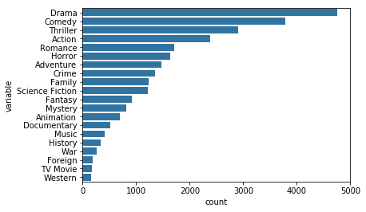

```python
order_type=bar_movie.variable.value_counts().index
base=sb.color_palette()[0]
sb.countplot(data=bar_movie,y='variable',color=base,order=order_type);
```

##### The chart shows that Drama , Comedy , Thriller , Action and Romance most movies in distribution of count of the movie by types

drop other types to do more analysis of them

```python
bar_movie.to_csv('bar_movie.csv')
```

```python
bar_movie.drop(bar_movie.query('variable != "Drama" and variable != "Comedy" and variable != "Thriller" and variable != "Action" and variable != "Romance" ').index,inplace=True)
```

## Bivariate Exploration

#### How many the rate of profit of movies over years ?

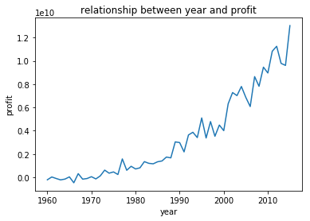

```python
plt.ylabel('profit')
plt.xlabel('year')
plt.title('relationship between year and profit')
plt.plot(movie_by_years['release_year'],movie_by_years['profit']);
```

##### The chart shows that sharp increas and decreas but Overall the profit is increas over the years.

##### and after 1990s has more increas then before

### How many the rate of popularity of movies over years ?

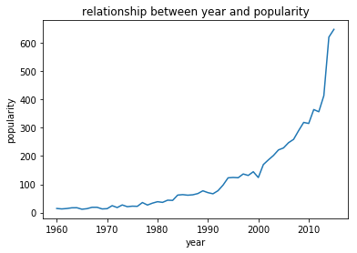

```python
plt.ylabel('popularity')
plt.xlabel('year')
plt.title('relationship between year and popularity')
plt.plot(movie_by_years['release_year'],movie_by_years['popularity']);
```

##### The chart shows popularity is smooth increas over the years conversely profit.

### what most year are produced from top five type of movies ?

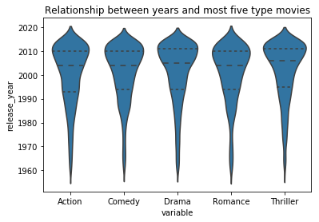

```python
g = sb.violinplot(data = bar_movie, y = 'release_year',
                 x = 'variable',color=base,inner = 'quartile')
plt.title('Relationship between years and most five type movies');
```

### How many profit came form each type from top five of type of movies ?

```python
pie=bar_movie.groupby('variable').sum()
pie.reset_index(inplace=True)
```

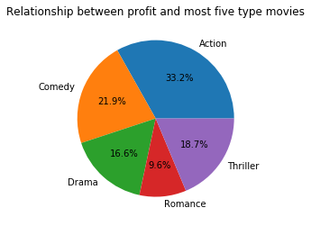

```python
plt.pie(pie.profit,labels=['Action','Comedy','Drama','Romance','Thriller'],autopct='%.1f%%');
plt.title('Relationship between profit and most five type movies');
```

##### The chart shows that Action , comedy and thriller is most three type have heigh profit

## Multivariate Exploration

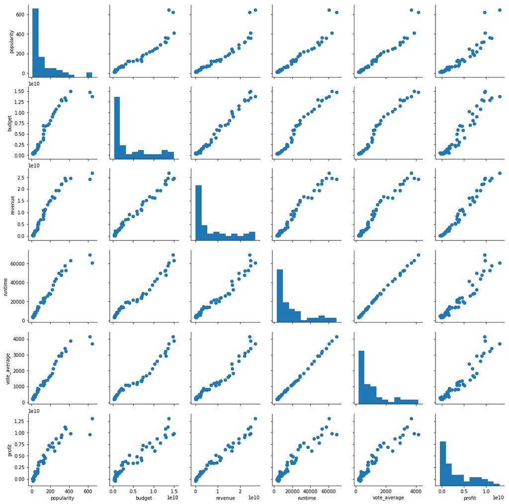

```python
g = sb.PairGrid(data = movie_by_years, vars = ['popularity',
'budget',
'revenue',
'runtime',
'vote_average',
'profit'])
g.map_diag(plt.hist)
g.map_offdiag(plt.scatter,s=40);
```

all scatter plot is increas but intensity of the rise is different between the variable.

## Conclusions

#### 1-the production companies heading towards produced Drama ,comedy , thriller, action and Romance

#### Action is in fourth type the produced type of movies but it get frist in profit and the Drama is in frist type produced type of movie but is get it fourth in profit

##### so should the production companies heading towards produced Action , Comedy , and Thriller to get more profit

#### 2- popularity and increas after 1990s has more increas then before and that explain why profit is increas more than before

#### 3-all scatter plot is increas but intensity of the rise is different between the variable.

```python
movie_by_years.to_csv('movies_by_years.csv')
```